# MA40198: Applied Statistical Inference

Lab 5: Delta method and Generalised likelihood ratio test

2024-10-24

[Go back to Moodle page](https://moodle.bath.ac.uk/course/view.php?id=1836&section=11)

This lab is about gaining a solid understanding of the use of asymptotic theory of maximum likelihood to obtain confidence intervals of nonlinear functions as well as performing hypothesis tests.

# Preliminaries

## Models for count data

The Poisson distribution is the simplest probability model for count data, e.g. taking values $0,1,2,\ldots$. The corresponding probability mass function is given by:

$$f(y|\mu)=\exp(-\mu)\,\frac{\mu^y}{y!}\quad y=0,1,2,3,4,....$$

where $\mu=E[Y]=Var[Y]$ which is a special property of the Poisson distribution. A slightly more general probability model is given by the Negative Binomial distribution with probability mass function:

$$f(y|\mu,\nu)={\nu+y-1 \choose y
}\left(\frac{\nu}{\mu+\nu}\right)^\nu\left(\frac{\mu}{\mu+\nu}\right)^y\quad
y=0,1,2,3,4,...$$

where $\mu=E[Y]>0$ and $\nu>0$. The corresponding variance is given by
$$Var[Y]=\mu\left(1+\frac{\mu}{\nu}\right)$$
It is easy to show that when $\nu\to \infty$ then the Negative Binomial distribution tends to the Poisson distribution with the same mean $\mu$. In this sense, we say that the Negative Binomial is overdispersed with respect to the Poisson.

In `R`, the density function of the Negative Binomial is computed using `dnbinom(x, size, prob, mu, log = FALSE)` where

- `x` is the count value e.g. $x = 0,1,2,\ldots$.
- `size` corresponds to the parameter $\nu$.
- `mu` corresponds to the mean $\mu$.
- `prob` is the probability of success $p=\nu/(\mu+\nu)$, similar to the Binomial. Apart from the mean $\mu$, the user should specify either $\nu$ or `prob`.
- `log = TRUE` returns the log density $\log f(x|\mu,\nu)$ and `log = FALSE` returns the density $f(x|\mu,\nu)$.

For the purposes of obtaining gradients, it is convenient to use the alternative expression:

$${\nu+y-1 \choose y }=\frac{\Gamma(\nu+y)}{\Gamma(y+1)\Gamma(\nu)}$$

where $\Gamma$ is the usual Gamma function. Relevant functions in R are `gamma` for the Gamma function $\Gamma$ and `lgamma` for the logarithm of the Gamma function.

## Delta method

Given an independent sample $y_1|\boldsymbol{x}_1,\ldots,y_n|\boldsymbol{x}_n$ where $\boldsymbol{x}_i\in \rel^p$ where each $\mathcal Y_i|\boldsymbol{x}_i$ follows an unknown density $f_*(y|\boldsymbol{x}_i)$ that is assumed to belong to a parametric family:
$$\mathcal F =
\left\{
f(y|\mu(\boldsymbol{\theta}^{(1)},\boldsymbol{x}),\boldsymbol{\theta}^{(2)})
\,:\,
\boldsymbol{\theta}=
\begin{pmatrix}
\boldsymbol{\theta}^{(1)}\\
\boldsymbol{\theta}^{(2)}\\
\end{pmatrix}
\in \boldsymbol{\Theta} \subseteq \rel^{p+m}
\right\}$$
we have seen in the lecture notes that, under some regularity assumptions, the maximum likelihood estimator $\widehat{\boldsymbol{\theta}}_n(\mathbfcal{Y})$ is asymptotically normal, that is:

$$\widehat{\boldsymbol{\theta}}_n(\mathbfcal{Y})-\boldsymbol{\theta}^*\stackrel{d}{\rightarrow}
N(\boldsymbol{0},\mathbfcal I^{-1}(\boldsymbol{\theta}^*))\quad
\mbox{as}\quad n\to \infty$$

where $\mathbfcal I({\boldsymbol{\theta}^*})$ is the **Fisher Information matrix** evaluated at $\boldsymbol{\theta}^*$.

If we consider a linear function of $\widehat{\boldsymbol{\theta}}_n(\mathbfcal{Y})$, that is
$$\boldsymbol{g}(\widehat{\boldsymbol{\theta}}_n(\mathbfcal{Y}))=\boldsymbol{A}\widehat{\boldsymbol{\theta}}_n(\mathbfcal{Y})$$
where $\boldsymbol{A}$ is a constant matrix of dimension $r\times (p+m)$ where $r \leq p+m$ then we clearly have that

$$\boldsymbol{A}\widehat{\boldsymbol{\theta}}_n(\mathbfcal{Y})-\boldsymbol{A}\boldsymbol{\theta}^*\stackrel{d}{\rightarrow}
N(\boldsymbol{0},\boldsymbol{A}\mathbfcal
I^{-1}(\boldsymbol{\theta}^*)\boldsymbol{A}^T)\quad \mbox{as}\quad n\to
\infty$$

Now consider general vector-valued (and possibly non-linear) smooth function of the form $\boldsymbol{g}:\rel^{p+m} \to \rel^r$ that is
$$\boldsymbol{g}(\boldsymbol{\theta}) =
\left(
\begin{array}{c}
g_1(\boldsymbol{\theta})\\
g_2(\boldsymbol{\theta})\\
\vdots\\
g_r(\boldsymbol{\theta})\\
\end{array}
\right)$$

for given differentiable real-valued functions $g_1,\ldots,g_r$ such that $g_i:\rel^{p+m}\to \rel$ for $i=1,\ldots,r$ where $r \leq p+m$.

## Delta Method

Under the assumptions **A1** to **A5** , a smooth function $\boldsymbol{g}:\rel^{p+m}\to \rel ^r$ of the maximum likelihood estimator is also asymptotically normal:

$$\boldsymbol{g}(\widehat{\boldsymbol{\theta}}_n(\mathbfcal{Y}))-\boldsymbol{g}(\boldsymbol{\theta}^*)\stackrel{d}{\rightarrow}
N(\boldsymbol{0},\boldsymbol{J}_{\boldsymbol{g}}(\boldsymbol{\theta}^*)\mathbfcal
I^{-1}(\boldsymbol{\theta}^*)\boldsymbol{J}^T_{\boldsymbol{g}}(\boldsymbol{\theta}^*))\quad
\mbox{as}\quad n\to \infty$$

where $\boldsymbol{J}_{\boldsymbol{g}}(\boldsymbol{\theta})$ is the Jacobian matrix

Recall the Jacobian matrix is defined by the following $r \times (p+m)$ derivative matrix:

$$\boldsymbol{J}_{\boldsymbol{g}}(\boldsymbol{\theta})=
\left(
\begin{array}{c}
\displaystyle \frac{\partial}{\partial
\boldsymbol{\theta}^T}g_1(\boldsymbol{\theta})\\
\displaystyle \frac{\partial}{\partial
\boldsymbol{\theta}^T}g_2(\boldsymbol{\theta})\\
\vdots\\
\displaystyle \frac{\partial}{\partial
\boldsymbol{\theta}^T}g_r(\boldsymbol{\theta})\\
\end{array}
\right)
=
\left(
\begin{array}{cccc}
\displaystyle \frac{\partial g_1(\boldsymbol{\theta})}{\partial
\theta_1} & \displaystyle \frac{\partial
g_1(\boldsymbol{\theta})}{\partial \theta_2} & \cdots &
\displaystyle \frac{\partial g_1(\boldsymbol{\theta})}{\partial
\theta_{p+m}}\\
\displaystyle \frac{\partial g_2(\boldsymbol{\theta})}{\partial
\theta_1} & \displaystyle \frac{\partial
g_2(\boldsymbol{\theta})}{\partial \theta_2} & \cdots &
\displaystyle \frac{\partial g_2(\boldsymbol{\theta})}{\partial
\theta_{p+m}}\\
\vdots & \vdots & \vdots & \vdots\\
\displaystyle\frac{\partial g_r(\boldsymbol{\theta})}{\partial \theta_1}
& \displaystyle\frac{\partial g_r(\boldsymbol{\theta})}{\partial
\theta_2} & \cdots & \displaystyle\frac{\partial
g_r(\boldsymbol{\theta})}{\partial \theta_{p+m}}\\
\end{array}
\right)$$

# Question 1

1. For the AIDS epidemic in Belgium data of [Lab 2](https://moodle.bath.ac.uk/pluginfile.php/2648537/mod_resource/content/1/Lab2_new.html) and assuming a Negative Binomial model with mean function $\mu(\boldsymbol{\theta}^*,t)=\exp(\theta^*_1+\theta^*_2\,t)$ where $t$ is the time since 1980, compute and plot the MLE of the probability that there are more than 250 AIDS cases as a function of $t$, that is:

$$P_*(Y_t>250|t)=1-\sum_{y=0}^{250}
{\nu_*+y-1 \choose y
}\left(\frac{\nu_*}{\mu(\boldsymbol{\theta}^*,t)+\nu_*}\right)^{\nu_*}\left(\frac{\mu(\boldsymbol{\theta}^*,t)}{\mu(\boldsymbol{\theta}^*,t)+\nu_*}\right)^y\,.$$

Also compute and plot 95% confidence bands for these probabilities and plot them as a function of $t$ in the range $(1,15)$.

```r
library(rlang)
mean_expr <- expr(theta1 + theta2 * t)
expr <- expr(-lgamma(v+y)+lgamma(y+1)+lgamma(v) - v*(log(v)-log(exp(!!mean_expr)+v))-y*(!!mean_expr-log(exp(!!mean_expr)+v)))
fn_deriv <- deriv(expr         = expr,
                  namevec      = c("theta1","theta2","v"),
                  function.arg = c("theta1","theta2","v","t","y"),
                  hessian      = T)

nll_fn <- function(theta  = c(1,1),
                   v      = 1,
                   t      = 1,
                   y      = 1){

 aux  <- fn_deriv(theta1 = theta[1],
                   theta2 = theta[2],
                   v,
                   t,
                   y)

 fn <- sum(as.numeric(aux))

 fn
}

nll_grad <- function(theta = c(1,1),
                     v     = 1,
                     t     = 1,
                     y     = 1){

  aux  <- fn_deriv(theta1 = theta[1],
                   theta2 = theta[2],
                   v,
                   t,
                   y)

  grad <- apply(attr(aux,"gradient"),2,sum)

 grad
}

tdat <- 1:13
ydat <- c(12,14,33,50,67,74,123 ,141 ,165 ,204 ,253,246,240 )

optim_1 <-
  optim(par = c(1,1,1),
      fn  = nll_fn,
      gr  = nll_grad,
      method = "BFGS",
      hessian = TRUE,
      t = tdat,
      y = ydat
      )
optim_1
```

```
## $par
## [1] 2.7180054 0.2528217 3.9697743
##
## $value
## [1] 71.39085
##
## $counts
## function gradient
##      206       12
##
## $convergence
## [1] 0
##
## $message
## NULL
##
## $hessian
##             [,1]          [,2]         [,3]
## [1,] 12.75301355  90.150491466  0.016233720
## [2,] 90.15049147 777.566674433 -0.006148475
## [3,]  0.01623372  -0.006148475  0.000000000
```

```r
vu <- optim_1$par[3]
```

**KAI Almost correct! You just did not pass the argument v in the correct way! see below for the correct way!**

```r
nll_fn <- function(theta  = c(1,1,1),
                   t      = 1,
                   y      = 1){

 aux  <- fn_deriv(theta1 = theta[1],
                   theta2 = theta[2],
                   v = theta[3],
                   t,
                   y)

 fn <- sum(as.numeric(aux))

 fn
}

nll_grad <- function(theta = c(1,1,1),
                     t     = 1,
                     y     = 1){

  aux  <- fn_deriv(theta1 = theta[1],
                   theta2 = theta[2],
                   v= theta[3],
                   t,
                   y)

  grad <- apply(attr(aux,"gradient"),2,sum)

 grad
}


optim_1 <-
  optim(par = c(1,1,1),
      fn  = nll_fn,
      gr  = nll_grad,
      method = "BFGS",
      hessian = TRUE,
      t = tdat,
      y = ydat
      )
optim_1
```

```
## $par
## [1]  2.7990469  0.2429075 19.1905691
##
## $value
## [1] 59.4108
##
## $counts
## function gradient
##       77       32
##
## $convergence
## [1] 0
##
## $message
## NULL
##
## $hessian
##               [,1]         [,2]        [,3]
## [1,]  198.13804068 1.492749e+03 -0.06937757
## [2,] 1492.74876457 1.343641e+04  0.51605436
## [3,]   -0.06937757 5.160544e-01  0.01048242
```

```r
vu <- optim_1$par[3]
```

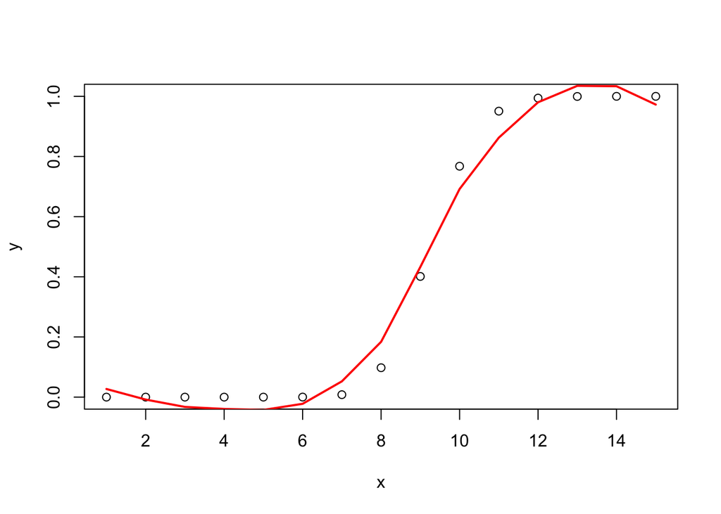

```r
fro <- function(x)
{
mu1 <- exp(optim_1$par[1]+ optim_1$par[2]*x)
 g <- rep(0,250)
 for(i in 0:250)
{
 g[i] <- (gamma(vu+i)/(gamma(i+1)*gamma(vu))) *
    ((vu/(mu1+vu))^vu) * ((mu1/(mu1+vu))^i)
 }
 g <- g[!g %in% c("Inf","NaN")]
 return(1-sum(g))
}
x <- c(1:15)
y <- rep(0,15)
for(i in 1:15)
{
 y[i] <- fro(i)
}

l <- loess(y~x)
plot(x,y)
lines(predict(l), col="red", lwd=2)
```

**KAI You can simply join the lines with `type="l"` rather than using `loess`**

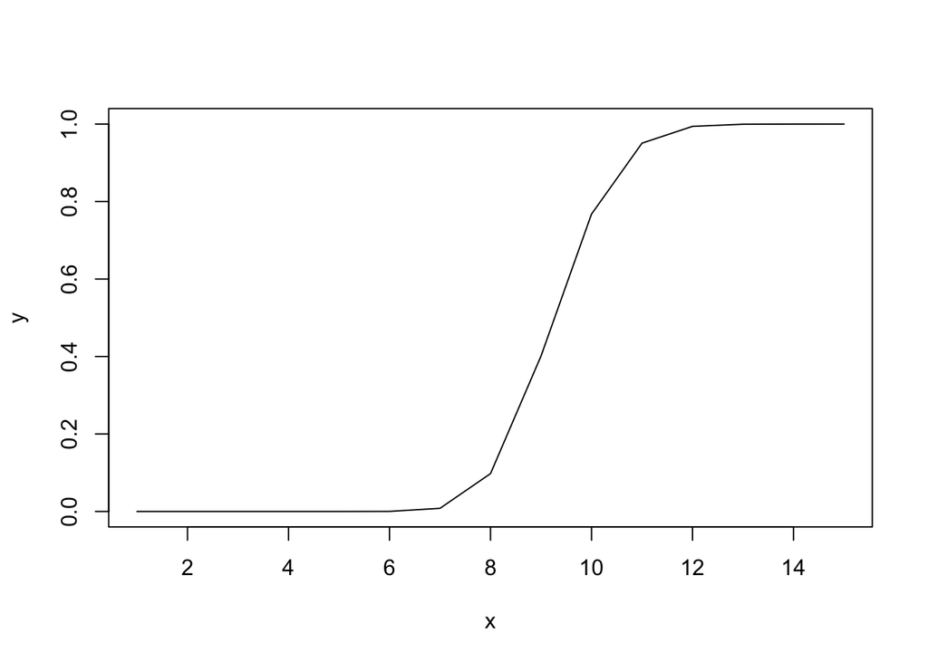

```r
plot(x,y,type="l")
```

**KAI** **You need to compoute the asymptotic variances using the delta method! and then compute the confidence bands! see solutions for details!!**

2. For regression data A in [Lab 3](https://moodle.bath.ac.uk/pluginfile.php/2653848/mod_resource/content/5/Lab3_new.html) and assuming a normal model, compute and plot (as a function of $x$) the MLE of the 90% quantile of the response given by:
   $$y_{90}=\theta_1^*+\theta^*_2\,\,x +
   z_{0.9}\,\sqrt{\nu_*}=\theta_1^*+\theta_2^*\,\,x +
   1.281552\,\sqrt{\nu_*}$$
   This is the value that
   $$P_*(\mathcal Y\leq y_{90}|X=x)=0.9\,.$$
   Here $z_{0.9}$ is the 90% of a standard normal distribution. Also compute and plot 95% confidence bands for these quantiles and plot them as a function of $x$ in the range $(-3,3)$.

```r
data_A <- read.table("https://people.bath.ac.uk/kai21/ASI/data/Lab3_data_A.txt")
mean_expr <- expr(theta1 + theta2 * t)
expr <- expr((0.5)*log(2*pi*vu) + ((y-(!!mean_expr))**2)/(vu*2))
std_var <- expr((y-!!mean_expr)/exp(theta3))
neg_log_density_expr_normal <-
  expr(
    theta3
    + (1/2)*log(2*pi)
    + ((!!std_var)^2)/2
  )

fn_deriv1 <- deriv(expr         = neg_log_density_expr_normal,
                  namevec      = c("theta1","theta2","theta3"),
                  function.arg = c("theta1","theta2","theta3","t","y"),
                  hessian      = T)

nll_fn <- function(theta  = c(1,1,1),
                   t      = 1,
                   y      = 1){

 aux  <- fn_deriv1(theta1 = theta[1],
                   theta2 = theta[2],
                   theta3 = theta[3],
                   t,
                   y)

 fn <- sum(as.numeric(aux))

 as.matrix(fn)
}

nll_grad <- function(theta = c(1,1,1),
                     t     = 1,
                     y     = 1){

  aux  <- fn_deriv1(theta1 = theta[1],
                   theta2 = theta[2],
                   theta3 = theta[3],
                   t,
                   y)

  grad <- apply(attr(aux,"gradient"),2,sum)

 as.matrix(grad)
}

optim_2 <-
  optim(par = c(1,1,1),
      fn  = nll_fn,
      gr  = nll_grad,
      method = "BFGS",
      hessian = TRUE,
      t = data_A$x,
      y = data_A$y
      )

optim_2
```

```
## $par
## [1] 0.6775658 1.9097636 0.4834442
##
## $value
## [1] 190.2383
##
## $counts
## function gradient
##       21        8
##
## $convergence
## [1] 0
##
## $message
## NULL
##
## $hessian
##               [,1]         [,2]          [,3]
## [1,]  3.802645e+01 3.469447e-14 -2.635158e-04
## [2,]  3.469447e-14 5.172621e+01  7.061317e-03
## [3,] -2.635158e-04 7.061317e-03  2.000002e+02
```

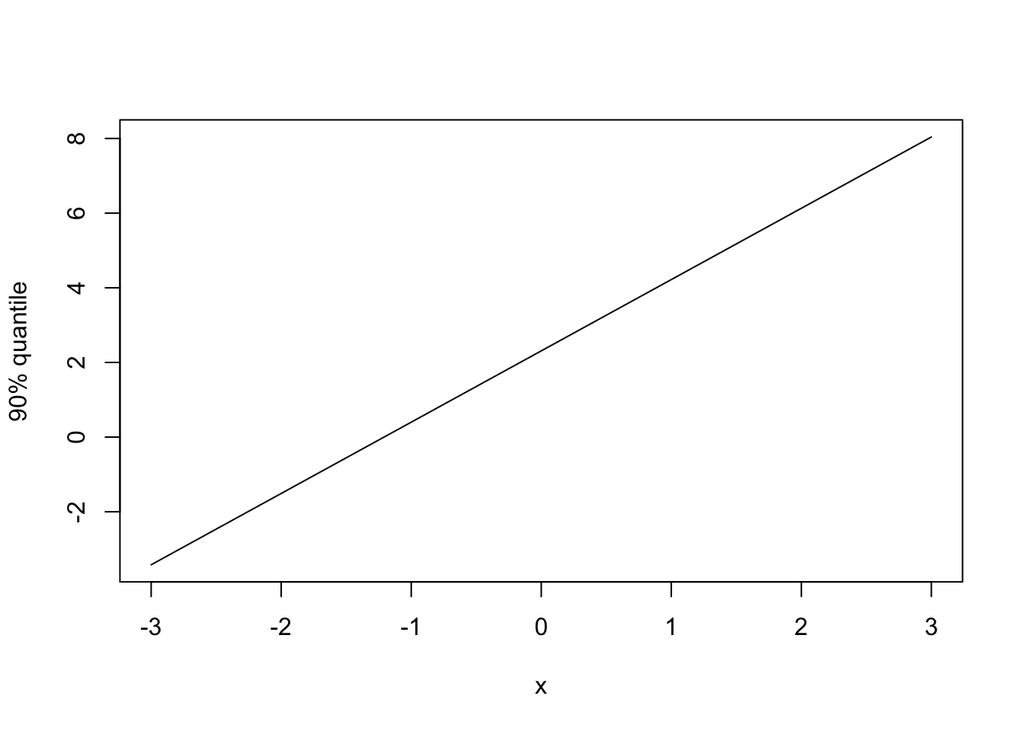

```r
curve(optim_2$par[1] + optim_2$par[2]*x + sqrt(exp(optim_2$par[3]))*qnorm(0.9), xlim=c(-3,3), ylab="90% quantile")
```

**KAI : exp(theta3) is already the standard deviation so no need to take sqrt! you can also add the data points for reference see below**

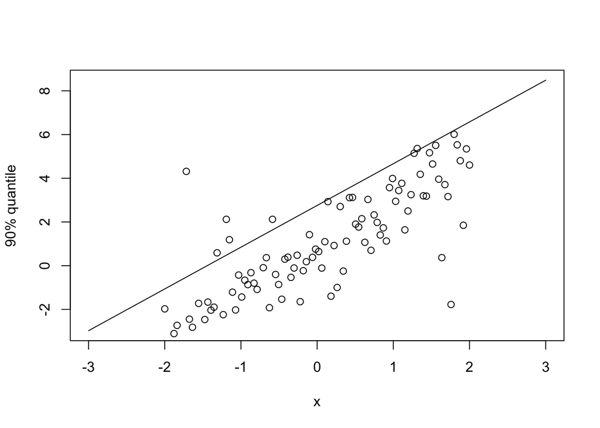

```r
curve(optim_2$par[1] + optim_2$par[2]*x + exp(optim_2$par[3])*qnorm(0.9), xlim=c(-3,3), ylab="90% quantile")
points(data_A)
```

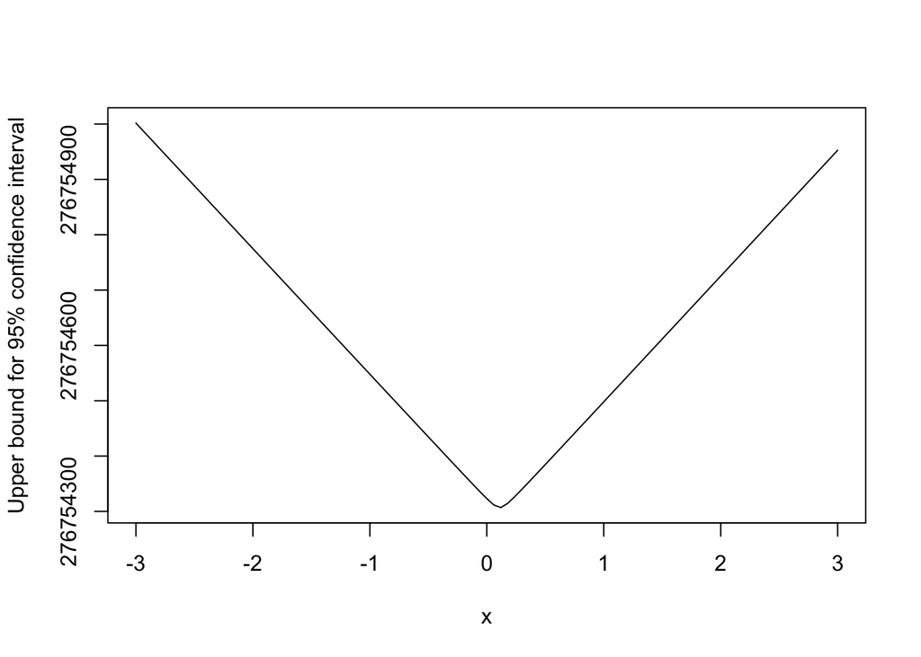

```r
## function for mean of 90% quantile
from1 <- function(x)
{
 optim_1$par[1] + optim_1$par[2]*x + #sqrt(exp(optim_1$par[3]))*qnorm(0.9) # KAI: changed this
  exp(optim_1$par[3])*qnorm(0.9)
}
## function for variance of 90% quantile
from <- function(x)
{
  optim_1$hessian[1,1]+(x^2)*optim_1$hessian[2,2]+(qnorm(0.9)^2)*optim_1$hessian[3,3] - 2*x*optim_1$hessian[1,2]-2*(qnorm(0.9))*optim_1$hessian[1,3] - 2*(qnorm(0.9))*x*optim_1$hessian[2,3]
}
## 95% confidence interval upper bound
curve(from1(x)+sqrt(from(x))*qnorm(0.975), xlim=c(-3,3), ylab="Upper bound for 95% confidence interval")
```

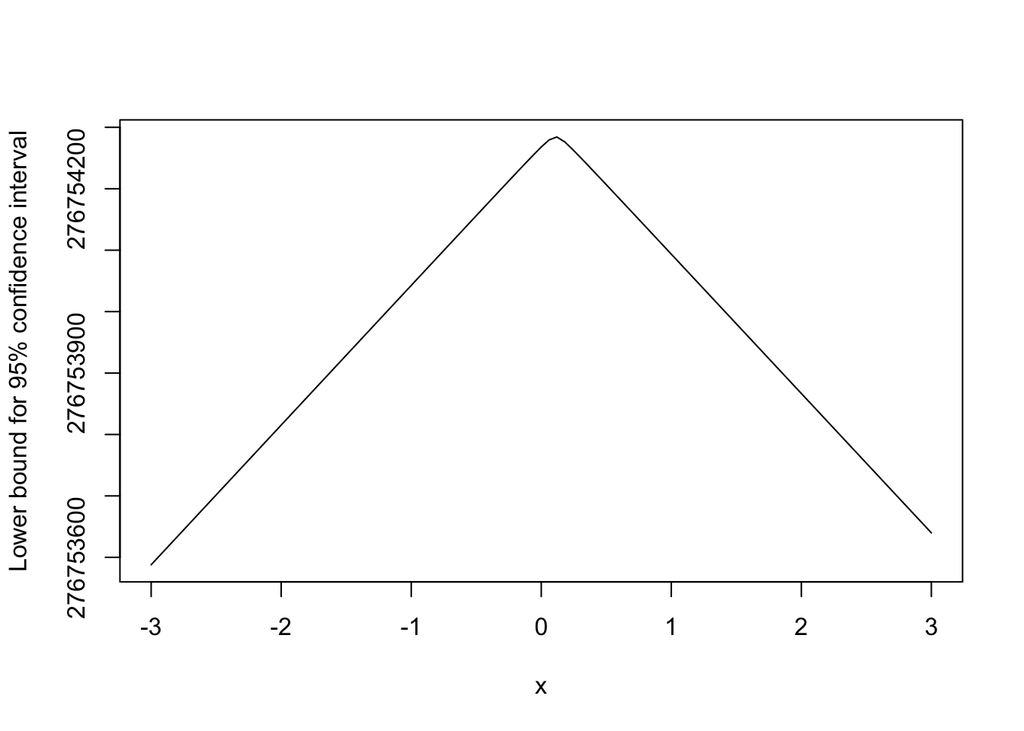

```r
## 95% confidence interval lower bound
curve(from1(x)-sqrt(from(x))*qnorm(0.975), xlim=c(-3,3), ylab="Lower bound for 95% confidence interval")
```

**KAI This is incorrect see solutions for details**